# Prosper Loan Data - Part I

## Multivariate Exploration

> In this section, we will explore a few of the earlier features in multivariate plots.

#### Investigation 1: Monthly Income vs Loan Amount vs Home Ownersip

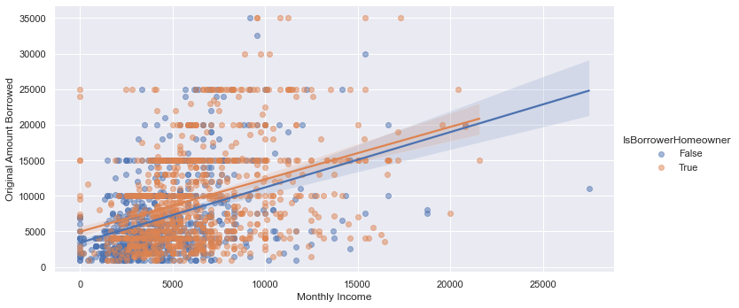

```python
g = sns.FacetGrid(data = prosper_data_rand, hue = "IsBorrowerHomeowner",
                height=5, aspect=2) # viridis used in reverse
g.map(sns.regplot, "StatedMonthlyIncome", "LoanOriginalAmount", x_jitter=0.5, y_jitter=0.5, fit_reg=True, scatter_kws={'alpha':5/10})
g.add_legend()
plt.xlabel("Monthly Income")
plt.ylabel("Original Amount Borrowed");
```

Home ownership doesnt's seem to affect the relationship between income and the amount borrowed, as the distribution seems to be fairly consistent across both groups.

#### Investigation 2: Loan Amount vs Borrower Rate vs Home Ownersip vs Employment Status

**Question:** What is the difference in how the loan amount affects borrower APR/rate by home ownership and Employment status?

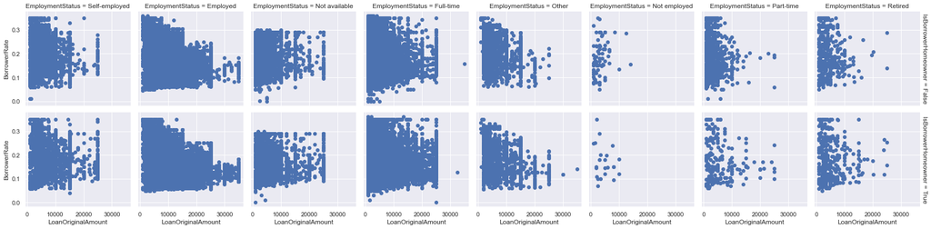

```python
# plot a multivariate Facet Grid to subset homeonwers from non homeowners for the loan amount and borrower rate relationship.

g = sns.FacetGrid(data = prosper_dataset, col = "EmploymentStatus", row = "IsBorrowerHomeowner", margin_titles=True)
g.map(plt.scatter, "LoanOriginalAmount", "BorrowerRate");
```

### Talk about some of the relationships you observed in this part of the investigation. Were there features that strengthened each other in terms of looking at your feature(s) of interest?

> The general trend we can see here from the multivariate analysis is that there is not much difference between how the Loan Amount borrowed affected the Rate in both home owners and non home owners, in the same way that there isn't much difference in how income affected how much they borrowed.

> However, we can clearly see the trend for both home owners and non-homeowners that people who are employed in one form or the other and have higher pay generally borrow more, which means they attract lower rates.

### Were there any interesting or surprising interactions between features?

> It was interesting to see how a risk score can tell how likely a borrower is to repay their loan. It was also interesting (and a bit surprising) to see that people borrowed to pay off an earlier debt.

## Conclusions

> In conclusion, the major predictors of whether a customer repays a loan or not are the amount of loan borrowed, borrower rate, APR, and prosper risk score. However, there is so much more that can be gotten from this dataset, if more exploration is done.

## Resources

- [Kimberly Fessel YouTube Channel](https://www.youtube.com/watch?v=NBYzSaTbodM)
- [Convert Value Counts To List - Stack Overflow](https://stackoverflow.com/questions/52436394/how-to-convert-a-pandas-value-counts-into-a-python-list)
- [Matplotlib Visualizations - Machine Learning +](https://www.machinelearningplus.com/plots/top-50-matplotlib-visualizations-the-master-plots-python/#34.-Bar-Chart)
- [Python Howtos - Study Tonight](https://www.studytonight.com/python-howtos/how-to-get-month-name-from-month-number-in-python)